# Portfolio Assignment 2: Danish Monarchs

Liv Lindeneg

26/05-2026

## Load the kings

##### 1. Look at the dataset that you are loading and check what its columns are separated by?

- In a plain text editor I can see that the columns are separated by: semicolons.

##### 2. Create a `kings` object in R with the different functions below and inspect the different outputs.

`read.csv()`

- It will not load the data and make a object with the first function `read.csv` - maybe because it is expecting columns separated by commas, but my columns are separated by semicolons. I get an error message that the data has more columns than column names - so another possibility is that it is able to split some of the data into columns but it is not able to split my column names.

`read_csv()`

- Does not separate my data in columns, the output of the function is just one big column with all the data in. The data is not separated into different columns for every variable.

`read.csv2()`

- This function is able to correctly read the semicolons and separate the columns.

`read_csv2()`

- This function also correctly separates the columns with the help of the semicolon.

```r
# TESTING DIFFERENT FUNCTIONS

kings1 <- read.csv("data/konger.csv") # Gives error - explaination above
```

```
## Error in `read.table()`:
## ! more columns than column names
```

```r
kings2 <- read_csv("data/konger.csv")
kings3 <- read.csv2("data/konger.csv")

kings4 <- read_csv2("data/konger.csv")
```

```
## ℹ Using "','" as decimal and "'.'" as grouping mark. Use `read_delim()` for more control.
```

##### 3. Answer:

Which of these functions is a `tidyverse` function?

- The `read_csv2()` is a tidyverse function and it will be used below to make the kings object.

What is the result of running `class()` on the `kings` object created with a tidyverse function.

- Running the `class()` function tells me that the kings object is a tibble data frame.

How many columns does the object have when created with these different functions?

Show the dataset so that we can see how R interprets each column

- The function `glimpse()` will show all the columns and how they are interpreted by R.

```r
# INSPECTING THE DATA

kings <- read_csv2("data/konger.csv")

class(kings)
```

```
## [1] "spec_tbl_df" "tbl_df"      "tbl"         "data.frame"
```

```r
ncol(kings)
```

```
## [1] 8
```

```r
glimpse(kings)
```

```
## Rows: 55
## Columns: 8
## $ name                 <chr> "Gorm_den_gamle", "Harald_1_blaatand", "Svend_1_t…
## $ birth_year           <dbl> NA, NA, 963, NA, 995, 1020, 1024, 1020, 1040, 104…
## $ start_reign          <dbl> NA, NA, NA, 1014, 1018, 1035, 1042, 1047, 1076, 1…
## $ death_year           <dbl> 958, 987, 1014, 1018, 1035, 1042, 1047, 1076, 108…
## $ end_reign            <dbl> 958, 987, 1014, 1018, 1035, 1042, 1047, 1076, 108…
## $ uncertain_birthyear  <chr> "yes", "yes", "no", "yes", "yes", "no", "no", "ye…
## $ uncertain_deathyear  <chr> "yes", "yes", "no", "yes", "no", "no", "no", "no"…
## $ uncertain_reignstart <chr> "yes", "yes", "yes", "no", "no", "no", "no", "yes…
```

## Calculate the duration of reign for all the kings in your table

Create a new column called `duration` in the kings dataset, utilizing the `mutate()` function from tidyverse.

- Using the `mutate()` function to make a new column in the dataset over duration of reign.
- To calculate the duration in the `mutate()` function the “start_reign” column has been subtracted form the “end_reign” column.
- Then using the `glimpse()` function it is possible to see the new column.

```r
# DURATION OF REIGN FOR ALL THE KINGS

kings <- kings %>%
  mutate(duration = end_reign - start_reign)

glimpse(kings)
```

```
## Rows: 55
## Columns: 9
## $ name                 <chr> "Gorm_den_gamle", "Harald_1_blaatand", "Svend_1_t…
## $ birth_year           <dbl> NA, NA, 963, NA, 995, 1020, 1024, 1020, 1040, 104…
## $ start_reign          <dbl> NA, NA, NA, 1014, 1018, 1035, 1042, 1047, 1076, 1…
## $ death_year           <dbl> 958, 987, 1014, 1018, 1035, 1042, 1047, 1076, 108…
## $ end_reign            <dbl> 958, 987, 1014, 1018, 1035, 1042, 1047, 1076, 108…
## $ uncertain_birthyear  <chr> "yes", "yes", "no", "yes", "yes", "no", "no", "ye…
## $ uncertain_deathyear  <chr> "yes", "yes", "no", "yes", "no", "no", "no", "no"…
## $ uncertain_reignstart <chr> "yes", "yes", "yes", "no", "no", "no", "no", "yes…
## $ duration             <dbl> NA, NA, NA, 4, 17, 7, 5, 29, 4, 6, 9, 8, 30, 3, 9…
```

## Calculate the average duration of reign for all rulers

- Using both the `mean()` function on a vector and the `summarise()` function on a tibble I get the same result.
- When using both functions it is important to remove missing data, in both functions `na.rm=TRUE` has been used.
- The average duration of the danish monarchs reign is 19.8 years.

```r
# AVERAGE DURATION OF REIGN

# Using the column duration as a vector and the mean() function
mean(kings$duration, na.rm = TRUE)
```

```
## [1] 19.80392
```

```r
# Using the summarise() function on a tibble
kings %>%
  summarise(mean_duration = mean(duration, na.rm = TRUE))
```

```
## # A tibble: 1 × 1
##   mean_duration
##           <dbl>
## 1          19.8
```

## How many and which kings enjoyed a longer-than-average duration of reign?

```r
# LONGER THAN AVERAGE REIGN

kings %>%
  select(name, duration) %>%
  filter(duration > 20)
```

```
## # A tibble: 22 × 2
##    name                 duration
##    <chr>                   <dbl>
##  1 Svend_2_estridsen          29
##  2 Niels                      30
##  3 Valdemar_1_den_store       36
##  4 Valde_2_sejr               39
##  5 Erik_5_klipping            27
##  6 Erik_6_menved              33
##  7 Valdemar_4_atterdag        35
##  8 Erik_7_af_pommern          43
##  9 Christian_1                33
## 10 Hans                       31
## # ℹ 12 more rows
```

```r
count(filter(kings,duration>20))
```

```
## # A tibble: 1 × 1
##       n
##   <int>
## 1    22
```

## How many days did the three longest-ruling monarchs rule?

- First using the `select()` function to only grab the name and duration column.
- After that using the `arrange()` function will sort duration in descending order.
- Using the `slice_head()` function a to get only the three longest ruling monarchs.
- Then at the end using the `mutate()` to create a new column over days.

```r
# THREE LONGEST RULING MONARCHS

kings %>%
  select(name, duration) %>%
  arrange(desc(duration)) %>%
  slice_head(n=3) %>%
  mutate(days = duration*365)
```

```
## # A tibble: 3 × 3
##   name              duration  days
##   <chr>                <dbl> <dbl>
## 1 Christian_4             52 18980
## 2 Margrete_2              52 18980
## 3 Erik_7_af_pommern       43 15695
```

## Plot the kings’ duration of reign through time

What is the long-term trend in the duration of reign among Danish monarchs? How does it relate to the historical violence trends?

- First going to make a new object just for the plotting.
- In the new object with the `mutate()` function making a new column called “mid_year”, with the instructions given for this task.
- Then combining the `geom_point()` function with the `geom_smooth()` function, choosing the “mid_year” as the x axis and “duration” as the y axis.
- At the end trying to customize the plots, by adding titles and labels, and also changing the theme.

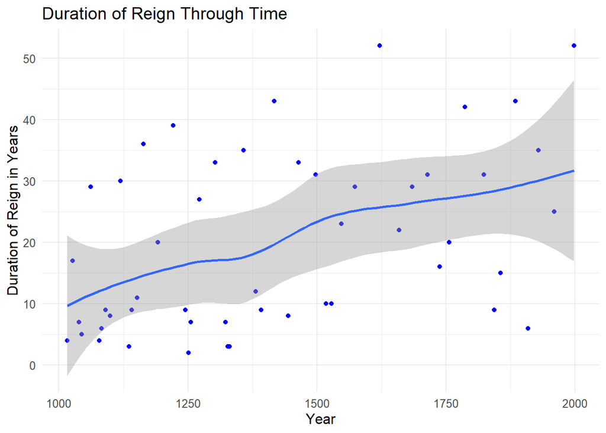

```r
# TRYING TO PLOT THE KINGS DURATION OF REIGN

kings %>%
  mutate(mid_year=(start_reign+(end_reign-start_reign)/2)) %>%
  ggplot(aes(x = mid_year, y = duration))+
  geom_point(color="blue")+
  geom_smooth()+
  labs(title = "Duration of Reign Through Time",
       x = "Year",
       y = "Duration of Reign in Years") +
  theme_minimal()+
  theme(text = element_text(size = 12))
```

```r
ggsave("DurationReign.png", width=10, height=6, dpi = 150)
```